# Querying Soil Series Data

D.E. Beaudette

2026-03-17

# 1 Introduction

This tutorial covers some of the new functionality in `soilDB` related to searching the USDA-NRCS Official (soil) Series Descriptions (OSDs) and working with summaries compiled by soil series name. Source data are the latest SSURGO snapshot (2018-10-01) and [*parsed*](https://github.com/dylanbeaudette/parse-osd) [OSD records](https://soilseries.sc.egov.usda.gov/) as of 2018-10-01. These data were developed to support various components of [SoilWeb](http://casoilresource.lawr.ucdavis.edu/soilweb/), including [SoilWeb Gmaps](https://casoilresource.lawr.ucdavis.edu/gmap/), [Series Extent Explorer](https://casoilresource.lawr.ucdavis.edu/see/), and [Series Data Explorer](https://casoilresource.lawr.ucdavis.edu/sde/?series=davidson).

# 2 The Soil Series Concept

*[Excerpt from the Soil Survey Manual](https://www.nrcs.usda.gov/wps/portal/nrcs/detail/soils/ref/?cid=nrcs142p2_054254#soil_id)*

The series represents a three-dimensional soil body having a unique combination of properties that distinguish it from neighboring series. The soil series concept was developed more than 100 years ago and somewhat followed the logic of the series as used to describe sediments in the geologic cross-section. Like the geologic formation, the soil series has served as the fundamental mapping concept. In geology, strata closely related in terms of their properties and qualities were members of a series in the sedimentary record. Initially, the soil series did not conform to a specific taxonomic class nor property class limits but rather to the predominant properties and qualities of the soil landscape, climate, and setting in which the soil occurred.

Today, the soil series category is the lowest level and the most homogeneous category in the U.S. system of taxonomy. As a class, a series is a group of soils or polypedons that have horizons similar in arrangement and in differentiating characteristics. The soils of a series have a relatively narrow range in sets of properties. Although part of Soil Taxonomy, soil series are not recorded in it.

*Soil Science Division Staff. 2017. Soil survey manual. C. Ditzler, K. Scheffe, and H.C. Monger (eds.). USDA Handbook 18. Government Printing Office, Washington, D.C.*

## 2.1 An Official (soil) Series Description

The [Official Series Descriptions](https://www.nrcs.usda.gov/wps/portal/nrcs/detail/soils/survey/class/data/?cid=nrcs142p2_053586) (OSD) contain definitions and relevant information on all soil series. The narrative style of the OSD makes it possible for specialists and non-specialists to extract relevant details. For example, a soil scientist may consult a number of OSDs to determine if a new set of samples can be allocated to an existing soil series. A farmer might use the “typical pedon” narrative and drainage class description when considering the purchase of a new parcel.

The OSDs are stored as text files with a [standardized format](https://www.nrcs.usda.gov/wps/portal/nrcs/detail/soils/ref/?cid=nrcs142p2_054254#records). Deviations from the standard format, changes through time, local variation in style, and typos (manual and / or OCR-related) aren’t an issue for human readers but have complicated the analysis by machine for decades. There are plans in place for a structured database that would ultimately be used to generate the OSD narrative. Until that time, there are only a couple ways in which the OSD data can be searched:

- as indexed / queried by links to the the [Soil Classification database](https://www.nrcs.usda.gov/wps/portal/nrcs/detail/soils/survey/geo/?cid=nrcs142p2_053587)
- [full text searching of the parsed OSD database](http://soilmap2-1.lawr.ucdavis.edu/osd-search/)

As an example, here is the OSD for the Davidson soil series.

[interactive chart not shown]

# 3 Setup

With a recent version of R (>= 2.15), it is possible to get all of the packages that this tutorial depends on via:

```r
# stable packages from CRAN
install.packages('aqp')
install.packages('soilDB')
install.packages('sharpshootR')
install.packages('dendextend')

# latest versions from GitHub
devtools::install_github("ncss-tech/aqp", dependencies=FALSE, upgrade_dependencies=FALSE)
devtools::install_github("ncss-tech/soilDB", dependencies=FALSE, upgrade_dependencies=FALSE)
devtools::install_github("ncss-tech/sharpshootR", dependencies=FALSE, upgrade_dependencies=FALSE)
```

## 3.1 Using this Tutorial

This tutorial can be used as a stand-alone demonstration of the functionality provided by `fetchOSD` and `OSDquery`, or as a template for your own project. Copy any paste blocks of code *sequentially* into your own script if you would like to follow-along.

First, you will need to load some packages. Be sure to install these if missing, and install the latest versions of `soilDB` and `sharpshootR` as much of this tutorial depends on recent updates.

```r
library(aqp)
library(soilDB)
library(sharpshootR)
library(dendextend)
library(latticeExtra)
library(ggplot2)
library(RColorBrewer)
```

# 4 Examples

The following examples can be readily adapted to your own needs by copying/pasting the code chunks into a new R script.

## 4.1 Getting Basic Soil Morphology and Taxonomic Data

The `fetchOSD` function provides an interface to the parsed OSD records, hosted by SoilWeb. These records contain a combination of horizon-level and site-level attributes, returned as a `SoilProfileCollection` object. Site-level attributes include: latest taxonomic data from the SC database and an acreage estimate. Horizon-level attributes include horizon depths (cm), designations, moist/dry colors, pH, and texture. The original horizon narrative is also included. Moist soil colors are converted by default to sRGB values suitable for on-screen display.

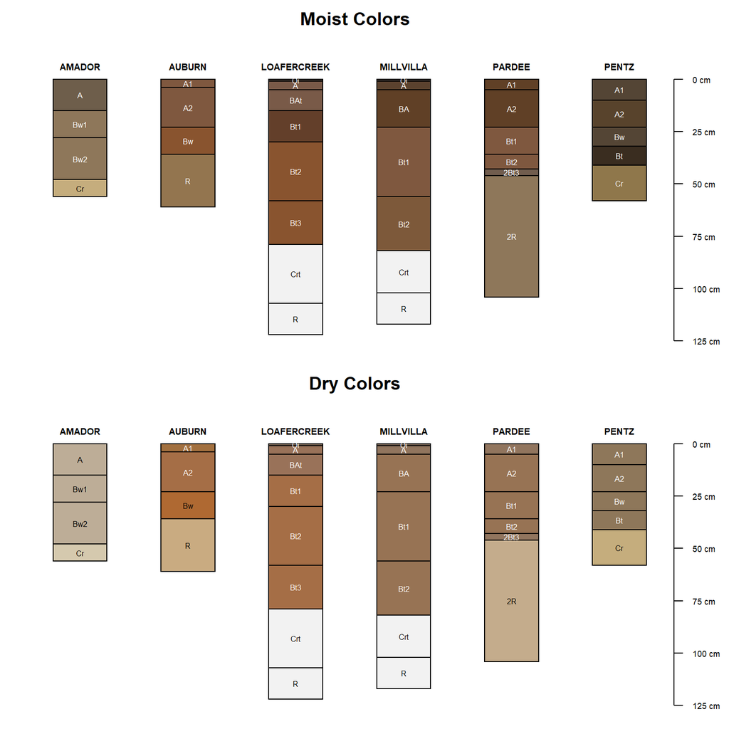

```r
# a vector of named soil series
# the search is case insensitive
soils <- c('amador', 'pentz', 'pardee', 'auburn', 'loafercreek', 'millvilla')

# moist colors are converted from Munsell -> sRGB by default
s <- fetchOSD(soils)
# also convert dry colors
s.dry <- fetchOSD(soils, colorState = 'dry')

# quickly compare moist to dry colors
par(mar = c(1,0,2,1), mfrow = c(2,1))
plotSPC(s, name.style = 'center-center') ; title('Moist Colors')
plotSPC(s.dry, name.style = 'center-center') ; title('Dry Colors')
```

The `SoilTaxonomyDendrogram` function from `sharpshootR` package knows how to use elements from the soil classification (order/suborder/great group/subgroup) to build a unique layout of profile sketches. The dissimilarity matrix is computed using Gower’s distance metric for nominal data.

| id | soilorder | suborder | greatgroup | subgroup |
| --- | --- | --- | --- | --- |
| AMADOR | inceptisols | xerepts | haploxerepts | typic haploxerepts |
| AUBURN | inceptisols | xerepts | haploxerepts | lithic haploxerepts |
| LOAFERCREEK | alfisols | xeralfs | haploxeralfs | ultic haploxeralfs |
| MILLVILLA | alfisols | xeralfs | haploxeralfs | ultic haploxeralfs |
| PARDEE | alfisols | xeralfs | haploxeralfs | lithic mollic haploxeralfs |
| PENTZ | mollisols | xerolls | haploxerolls | ultic haploxerolls |

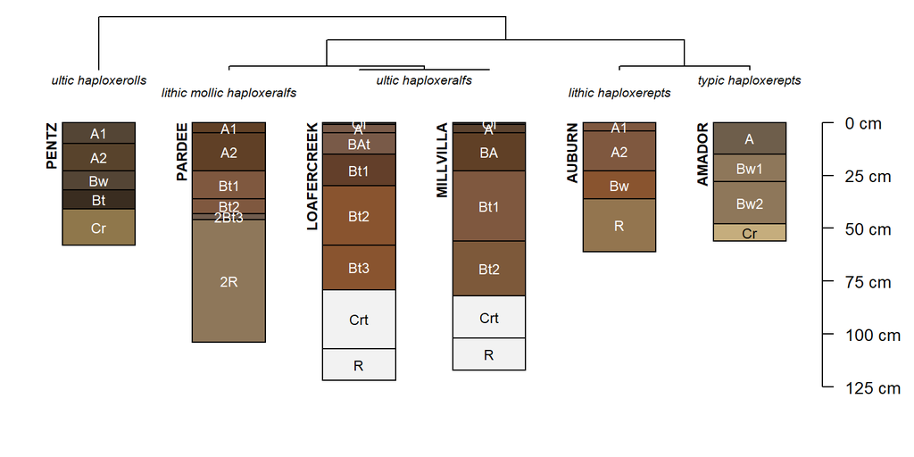

```r
par(mar = c(0, 0, 1, 1))
SoilTaxonomyDendrogram(s, scaling.factor = 0.02, width = 0.28, name.style = 'center-center', depth.axis = list(line = -4))
```

```r
# internal structure, note that this is an S4 object with slots
str(s)
# site-level attribute names
siteNames(s)
# horizon-level attribute names
horizonNames(s)
```

### 4.1.1 Important Assumptions and Limitations

Here are the narratives associated with the first profile in the collection. Regular expression was used to extract specific morphologic data. Some data may be missing or incorrect due to formatting errors, inconcsistencies, or typos. Many of the OSDs were converted from paper copies via OCR.

A–0 to 15 cm; light gray (10YR 7/2) loam, dark grayish brown (10YR 4/2) moist; moderate coarse subangular blocky structure; slightly hard, friable, slightly sticky and slightly plastic; many very fine roots; many very fine and few fine tubular and many very fine interstitial pores; 10 percent gravel; strongly acid (pH 5.1); clear wavy boundary. (3 to 20 cm thick)

Bw1–15 to 28 cm; light gray (10YR 7/2) loam, brown (10YR 5/3) moist; weak medium subangular blocky structure; slightly hard, friable, slightly sticky and slightly plastic; common very fine roots; many very fine and common fine tubular and many very fine interstitial pores; 5 percent gravel; strongly acid (pH 5.1); clear wavy boundary.

Bw2–28 to 48 cm; light gray (10YR 7/2) loam, brown (10YR 5/3) moist; weak medium subangular blocky structure; slightly hard, friable, slightly sticky and slightly plastic; many very fine and common fine tubular and many very fine interstitial pores; few thin colloidal stains on mineral grains, 10 percent gravel mostly at the base of horizon; very strongly acid (pH 5.0); abrupt wavy boundary. (Combined thickness of the Bw horizons is 23 to 41 cm)

Cr–48 to 56 cm; pale yellow (2.5Y 8/2) weakly consolidated rhyolitic tuffaceous sediments, pale yellow (2.5Y 7/4) moist; very strongly acid (pH 4.5).

Here are the data elements extracted from the narratives above. Depths are always converted to cm. Note that not all of the morphologic data have been recovered.

| top | bottom | hzname | soil_color | hue | value | chroma | dry_hue | dry_value | dry_chroma | texture_class | cf_class | pH | pH_class |
| --- | --- | --- | --- | --- | --- | --- | --- | --- | --- | --- | --- | --- | --- |
| 0 | 15 | A | #6E5E4BFF | 10YR | 4 | 2 | 10YR | 7 | 2 | loam | NA | 5.1 | strongly acid |
| 15 | 28 | Bw1 | #8E775AFF | 10YR | 5 | 3 | 10YR | 7 | 2 | loam | NA | 5.1 | strongly acid |
| 28 | 48 | Bw2 | #8E775AFF | 10YR | 5 | 3 | 10YR | 7 | 2 | loam | NA | 5.0 | very strongly acid |
| 48 | 56 | Cr | #C5AD7DFF | 2.5Y | 7 | 4 | 2.5Y | 8 | 2 | NA | NA | 4.5 | very strongly acid |

## 4.2 Extended Summaries

Take a peek at the new extended summaries. [Background on how concepts such as “parent material”, “surface shape”, and “geomorphic component” are descirbed within USDA-NRCS soil survey data](https://www.nrcs.usda.gov/wps/portal/nrcs/detail/soils/ref/?cid=nrcs142p2_054252).

```r
soils <- c('argonaut', 'pierre', 'zook', 'cecil')
s <- fetchOSD(soils, extended = TRUE)

# note additional data, packed into a list
str(s, 1)
```

```
## List of 19
##  $ SPC             :Formal class 'SoilProfileCollection' [package "aqp"] with 8 slots
##  $ competing       :'data.frame':    35 obs. of  3 variables:
##  $ geog_assoc_soils:'data.frame':    30 obs. of  2 variables:
##  $ geomcomp        :'data.frame':    4 obs. of  9 variables:
##  $ hillpos         :'data.frame':    4 obs. of  8 variables:
##  $ mtnpos          :'data.frame':    1 obs. of  9 variables:
##  $ terrace         :'data.frame':    2 obs. of  5 variables:
##  $ flats           :'data.frame':    1 obs. of  7 variables:
##  $ shape_across    :'data.frame':    4 obs. of  8 variables:
##  $ shape_down      :'data.frame':    4 obs. of  8 variables:
##  $ pmkind          :'data.frame':    7 obs. of  5 variables:
##  $ pmorigin        :'data.frame':    18 obs. of  5 variables:
##  $ geomorphons     :'data.frame':    4 obs. of  12 variables:
##  $ mlra            :'data.frame':    36 obs. of  4 variables:
##  $ ecoclassid      :'data.frame':    42 obs. of  5 variables:
##  $ climate.annual  :'data.frame':    32 obs. of  12 variables:
##  $ climate.monthly :'data.frame':    96 obs. of  14 variables:
##  $ NCCPI           :'data.frame':    4 obs. of  16 variables:
##  $ soilweb.metadata:'data.frame':    28 obs. of  2 variables:
```

Competing soil series are those series that share a family-level classification. For example, the soil series competing with [Cecil](https://casoilresource.lawr.ucdavis.edu/sde/?series=cecil) would have a family level classification of *fine, kaolinitic, thermic typic kanhapludults*. These data are sourced from the current snapshot of the Soil Classification database via SoilWeb.

| series | competing | family |
| --- | --- | --- |
| CECIL | SAW | fine, kaolinitic, thermic typic kanhapludults |
| CECIL | SPARTANBURG | fine, kaolinitic, thermic typic kanhapludults |
| CECIL | TARRUS | fine, kaolinitic, thermic typic kanhapludults |
| CECIL | TUMBLETON | fine, kaolinitic, thermic typic kanhapludults |
| CECIL | WEDOWEE | fine, kaolinitic, thermic typic kanhapludults |
| CECIL | APPLING | fine, kaolinitic, thermic typic kanhapludults |
| CECIL | BETHLEHEM | fine, kaolinitic, thermic typic kanhapludults |
| CECIL | GEORGEVILLE | fine, kaolinitic, thermic typic kanhapludults |
| CECIL | HERNDON | fine, kaolinitic, thermic typic kanhapludults |
| CECIL | LAURENS | fine, kaolinitic, thermic typic kanhapludults |
| CECIL | MADISON | fine, kaolinitic, thermic typic kanhapludults |
| CECIL | NANFORD | fine, kaolinitic, thermic typic kanhapludults |
| CECIL | NANKIN | fine, kaolinitic, thermic typic kanhapludults |
| CECIL | NEESES | fine, kaolinitic, thermic typic kanhapludults |
| CECIL | PACOLET | fine, kaolinitic, thermic typic kanhapludults |

Geographically associated soils.

| series | gas |
| --- | --- |
| CECIL | BELTLINE |
| CECIL | CATAULA |
| CECIL | CHAVIS |
| CECIL | CHESTATEE |
| CECIL | CULLEN |
| CECIL | DURHAM |
| CECIL | HARD LABOR |
| CECIL | HELENA |
| CECIL | HULETT |
| CECIL | LLOYD |
| CECIL | LOCKHART |
| CECIL | LOUISBURG |
| CECIL | MECKLENBURG |
| CECIL | RION |
| CECIL | ROLESVILLE |
| CECIL | VANCE |
| CECIL | WATEREE |
| CECIL | WORSHAM |

Hillslope position (2D) and geomorphic component (3D) probabilities have been estimated by series by dividing the number of component records assigned the each hillslope position or geomorphic component by the total number of component records. The number of records used and Shannon entropy are included to asess uncertainty.

Hillslope position (2D):

| series | Toeslope | Footslope | Backslope | Shoulder | Summit | n | shannon_entropy |
| --- | --- | --- | --- | --- | --- | --- | --- |
| ARGONAUT | 0.04 | 0.37 | 0.40 | 0.18 | 0.01 | 78 | 1.77 |
| CECIL | 0.00 | 0.00 | 0.30 | 0.36 | 0.34 | 1076 | 1.58 |
| PIERRE | 0.00 | 0.14 | 0.73 | 0.01 | 0.12 | 432 | 1.16 |
| ZOOK | 0.99 | 0.01 | 0.00 | 0.00 | 0.00 | 484 | 0.11 |

Geomorphic component (3D), for “hills”, “mountains”, “terraces”, and “flats”:

| series | Interfluve | Crest | Head Slope | Nose Slope | Side Slope | Base Slope | n | shannon_entropy |
| --- | --- | --- | --- | --- | --- | --- | --- | --- |
| ARGONAUT | 0.28 | 0.01 | 0.03 | 0.02 | 0.36 | 0.29 | 86 | 1.93 |
| CECIL | 0.56 | 0.02 | 0.00 | 0.02 | 0.40 | 0.00 | 826 | 1.22 |
| PIERRE | 0.05 | 0.00 | 0.03 | 0.08 | 0.84 | 0.00 | 114 | 0.86 |
| ZOOK | 0.00 | 0.00 | 0.00 | 0.00 | 0.00 | 1.00 | 96 | 0.00 |

| series | Mountaintop | Mountainflank | Upper third of mountainflank | Center third of mountainflank | Lower third of mountainflank | Mountainbase | n | shannon_entropy |
| --- | --- | --- | --- | --- | --- | --- | --- | --- |
| ARGONAUT | 0 | 1 | 0 | 0 | 0 | 0 | 1 | 0 |

| series | Tread | Riser | n | shannon_entropy |
| --- | --- | --- | --- | --- |
| PIERRE | 0.5 | 0.5 | 4 | 1 |
| ZOOK | 1.0 | 0.0 | 124 | 0 |

| series | Dip | Talf | Flat | Rise | n | shannon_entropy |
| --- | --- | --- | --- | --- | --- | --- |
| ZOOK | 0.28 | 0.72 | 0 | 0 | 655 | 0.85 |

Parent material kind and origin probabilities have been estimated in a similar manner. The summaries are in long format due to the large set of possible `pmkind` and `pmorigin` classes.

| series | pmkind | n | total | P |
| --- | --- | --- | --- | --- |
| ARGONAUT | Residuum | 48 | 59 | 0.8136 |
| ARGONAUT | Colluvium | 11 | 59 | 0.1864 |
| CECIL | Residuum | 761 | 887 | 0.8579 |
| CECIL | Saprolite | 126 | 887 | 0.1421 |
| PIERRE | Residuum | 108 | 111 | 0.9730 |
| PIERRE | Slope alluvium | 3 | 111 | 0.0270 |
| ZOOK | Alluvium | 284 | 284 | 1.0000 |

| series | pmorigin | n | total | P |
| --- | --- | --- | --- | --- |
| ARGONAUT | Andesite | 11 | 58 | 0.1897 |
| ARGONAUT | Metasedimentary rock | 11 | 58 | 0.1897 |
| ARGONAUT | Igneous and metamorphic rock | 10 | 58 | 0.1724 |
| ARGONAUT | Diabase | 10 | 58 | 0.1724 |
| ARGONAUT | Metavolcanics | 9 | 58 | 0.1552 |
| ARGONAUT | Metamorphic rock | 5 | 58 | 0.0862 |
| ARGONAUT | Slate | 1 | 58 | 0.0172 |
| ARGONAUT | Shale | 1 | 58 | 0.0172 |
| CECIL | Granite and gneiss | 429 | 975 | 0.4400 |
| CECIL | Schist | 231 | 975 | 0.2369 |
| CECIL | Granite | 134 | 975 | 0.1374 |
| CECIL | Gneiss | 132 | 975 | 0.1354 |
| CECIL | Igneous and metamorphic rock | 43 | 975 | 0.0441 |
| CECIL | Metamorphic rock | 3 | 975 | 0.0031 |
| CECIL | Mica schist | 3 | 975 | 0.0031 |
| PIERRE | Shale | 68 | 108 | 0.6296 |
| PIERRE | Clayey shale | 27 | 108 | 0.2500 |
| PIERRE | Sandstone and shale | 13 | 108 | 0.1204 |

A rough approximation of MLRA membership has been computed by taking the intersection of all map unit polygons and current MLRA polygons. Membership values are based on intsersecting areas weighted by component percentage divided by total soil series area.

| series | mlra | area_ac | membership |
| --- | --- | --- | --- |
| ARGONAUT | 18 | 35127 | 0.829 |
| ARGONAUT | 17 | 3073 | 0.073 |
| ARGONAUT | 19 | 2252 | 0.053 |
| ARGONAUT | 22A | 1805 | 0.043 |
| ARGONAUT | 15 | 103 | 0.002 |

Annual and monthly climate summaries have been estimated from the [SSR2 standard stack of 1981–2010 PRISM data](https://ncss-tech.github.io/soilReports/docs/region2_mu-comparison-data-sources.html). For now, percentiles are estimates from a single sample from within each map unit polygon, weighted by *l**o**g*(*p**o**l**y**g**o**n* *a**r**e**a* * *c**o**m**p**o**n**e**n**t* *p**e**r**c**e**n**t**a**g**e*).

|  | series | climate_var | minimum | q01 | q05 | q25 | q50 | q75 | q95 | q99 | maximum | n |
| --- | --- | --- | --- | --- | --- | --- | --- | --- | --- | --- | --- | --- |
| 12 | ARGONAUT | Frost-Free Days | 184.00 | 215.41 | 242.05 | 277.00 | 310.00 | 323.00 | 345.00 | 351.00 | 365.00 | 842 |
| 13 | ARGONAUT | Elevation (m) | 4.00 | 60.00 | 78.00 | 140.25 | 270.00 | 436.00 | 753.35 | 983.03 | 1271.00 | 842 |
| 16 | ARGONAUT | Mean Annual Air Temperature (degrees C) | 12.33 | 14.06 | 14.82 | 15.51 | 16.13 | 16.46 | 16.66 | 16.84 | 17.00 | 842 |
| 20 | ARGONAUT | Mean Annual Precipitation (mm) | 498.00 | 568.00 | 591.00 | 754.00 | 838.50 | 905.00 | 1094.00 | 1235.54 | 1509.00 | 842 |
| 24 | ARGONAUT | Growing Degree Days (degrees C) | 1894.00 | 2174.53 | 2307.25 | 2427.75 | 2537.00 | 2597.00 | 2623.00 | 2671.95 | 2745.00 | 842 |
| 28 | ARGONAUT | Fraction of Annual PPT as Rain | 93.00 | 96.00 | 97.00 | 99.00 | 99.00 | 99.00 | 99.00 | 99.00 | 100.00 | 842 |
| 29 | ARGONAUT | Effective Precipitation (mm) | -368.26 | -283.77 | -246.24 | -121.65 | -8.28 | 80.93 | 291.71 | 452.17 | 747.55 | 842 |
| 32 | ARGONAUT | Design Freeze Index (degrees C) | 0.00 | 0.00 | 0.00 | 0.00 | 0.00 | 2.00 | 6.00 | 10.18 | 35.00 | 842 |

|  | series | climate_var | minimum | q01 | q05 | q25 | q50 | q75 | q95 | q99 | maximum | n | month | variable |
| --- | --- | --- | --- | --- | --- | --- | --- | --- | --- | --- | --- | --- | --- | --- |
| 1 | ARGONAUT | pet11 | 23 | 25.00 | 26 | 27 | 28.0 | 28 | 29 | 29.00 | 41 | 842 | 11 | Potential ET (mm) |
| 2 | ARGONAUT | ppt8 | 1 | 1.00 | 1 | 2 | 2.0 | 4 | 4 | 4.00 | 5 | 842 | 8 | Precipitation (mm) |
| 3 | ARGONAUT | ppt7 | 0 | 0.00 | 0 | 0 | 0.0 | 0 | 0 | 1.00 | 1 | 842 | 7 | Precipitation (mm) |
| 15 | ARGONAUT | pet5 | 68 | 72.41 | 77 | 81 | 84.5 | 89 | 92 | 93.00 | 94 | 842 | 5 | Potential ET (mm) |
| 17 | ARGONAUT | pet12 | 11 | 13.00 | 13 | 14 | 14.0 | 15 | 15 | 15.00 | 27 | 842 | 12 | Potential ET (mm) |
| 18 | ARGONAUT | pet4 | 38 | 40.00 | 44 | 48 | 49.0 | 52 | 54 | 54.59 | 57 | 842 | 4 | Potential ET (mm) |

### 4.2.1 Climate Summaries

Here is an example visualization of the climate summaries using select percentiles.

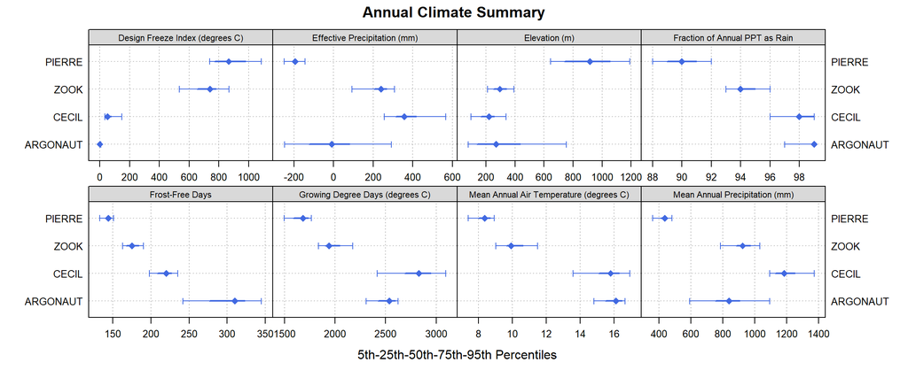

```r
# control color like this
trellis.par.set(plot.line = list(col = 'RoyalBlue'))

# control centers symbol and size here
res <- vizAnnualClimate(s$climate.annual, IQR.cex = 1.25, cex=1.1, pch=18)

print(res$fig)
```

One possible depiction of monthly PPT and PET.

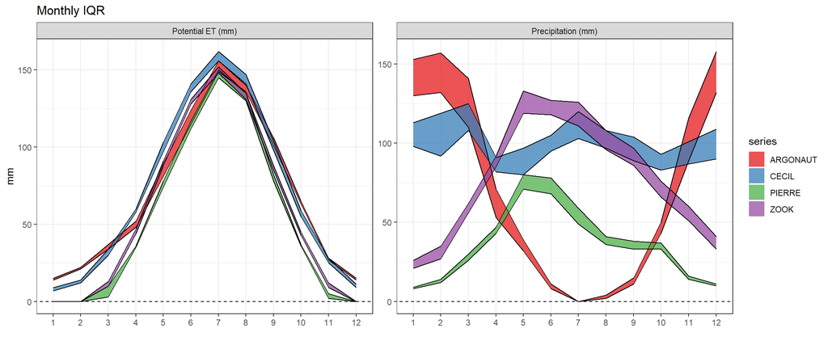

```r
# reasonable colors for a couple of groups
cols <- brewer.pal(9, 'Set1')
cols <- cols[c(1:5,7,9)]

ggplot(s$climate.monthly, aes(x = month, group=series)) +
  geom_ribbon(aes(ymin = q25, ymax = q75, fill=series)) +
  geom_line(aes(month, q25)) +
  geom_line(aes(month, q75)) +
  geom_abline(intercept=0, slope = 0, lty=2) +
  xlab('') + ylab('mm') +
  ggtitle('Monthly IQR') +
  scale_fill_manual(values=alpha(cols, 0.75)) +
  facet_wrap(vars(variable), scales = 'free_y') +
  theme_bw()
```

## 4.3 Vizualization of 2D and 3D Geomorphic Descriptions

Hillslope position.

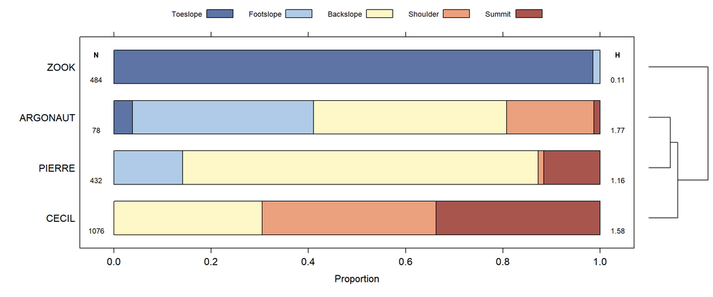

```r
# result is a lattice graphics object
res <- vizHillslopePosition(s$hillpos)
print(res$fig)
```

Geomorphic component for “hills”.

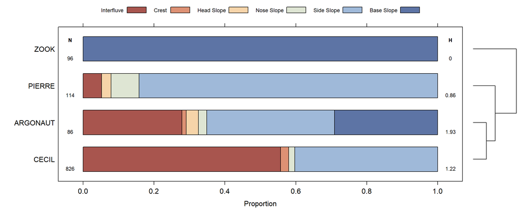

```r
# result is a lattice graphics object
res <- vizGeomorphicComponent(s$geomcomp)
print(res$fig)
```

# 5 Related Soils

## 5.1 Geographically Associated Soils

## 5.2 Siblings

Siblings are soils that exist in the same map unit, possibly limited to major components.

TODO: document major/minor siblings.

Get sibling data for [**Amador**](https://casoilresource.lawr.ucdavis.edu/sde/?series=amador) soil series via SoilWeb.

```r
# new function as of 2.2-8, single soil series at a time
s <- siblings('amador', component.data = TRUE)
```

Sibling data for the **Amador** soil series. The number of times each sibling occurs in a map unit with **Amador** is tabulated in the `n` column.

```r
kable_styling(kable(s$sib, format = 'html'), full_width = FALSE)
```

| series | sibling | majcompflag | n |
| --- | --- | --- | --- |
| amador | Pardee | TRUE | 8 |
| amador | Miltonhills | TRUE | 6 |
| amador | Gillender | TRUE | 2 |
| amador | Vleck | TRUE | 1 |
| amador | Miltonhills | FALSE | 15 |
| amador | Pardee | FALSE | 14 |
| amador | Redding | FALSE | 11 |
| amador | Hornitos | FALSE | 5 |
| amador | Gillender | FALSE | 5 |
| amador | Exchequer | FALSE | 4 |
| amador | Pentz | FALSE | 4 |
| amador | Vleck | FALSE | 2 |
| amador | Jennylind | FALSE | 2 |
| amador | Peters | FALSE | 2 |
| amador | Ranchoseco | FALSE | 2 |
| amador | Inks | FALSE | 1 |
| amador | Corning | FALSE | 1 |

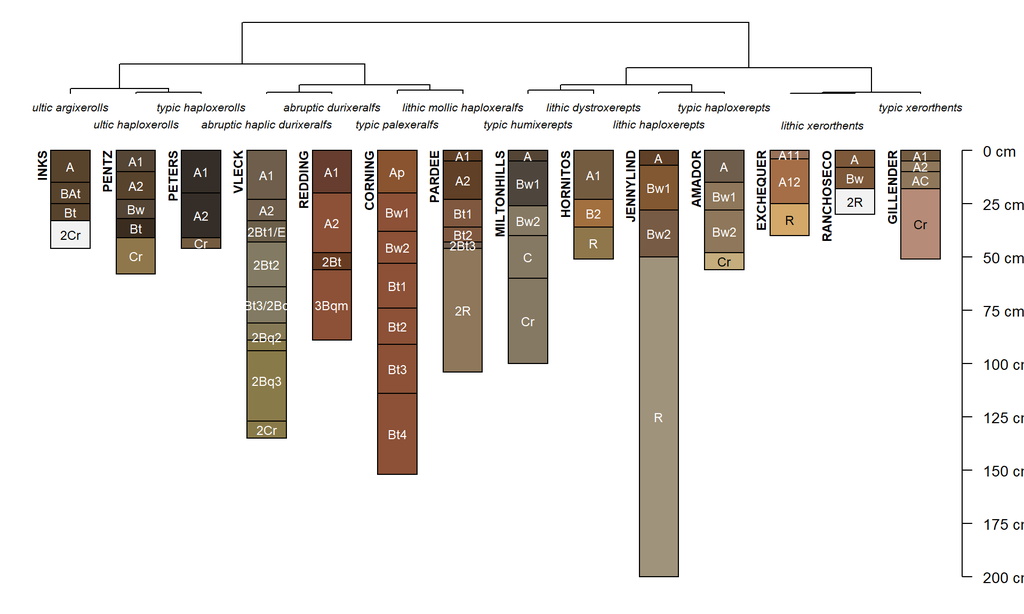

```r
# get basic OSD data for queried series and siblings
s.list <- unique(c(s$sib$series[1], s$sib$sibling))
h <- fetchOSD(s.list)

# plot dendrogram + profiles
SoilTaxonomyDendrogram(h, y.offset = 0.4, width = 0.3, name.style = 'center-center', depth.axis = list(line = -3))
```

Component data for the siblings of **Amador**. These can be used to generate a [co-occurence network](http://ncss-tech.github.io/AQP/sharpshootR/component-relation-graph.html).

```r
kable_styling(kable(head(s$sib.data), format = 'html'), full_width = FALSE)
```

| areasymbol | mukey | cokey | compname | comppct_r | compkind | majcompflag |
| --- | --- | --- | --- | --- | --- | --- |
| ca630 | 2600529 | 26412041 | Miltonhills | 50 | Series | Yes |
| ca630 | 2600529 | 26412042 | Amador | 30 | Series | Yes |
| ca630 | 2600529 | 26412043 | Ultic Argixerolls | 10 | Family | No |
| ca630 | 2600529 | 26412044 | Pardee | 5 | Series | No |
| ca630 | 2600529 | 26412045 | Rock outcrop | 5 | Miscellaneous area | No |
| ca630 | 2600537 | 26412054 | Urban land | 60 | Miscellaneous area | Yes |

Example co-occurence networks for the **Amador** series and siblings.

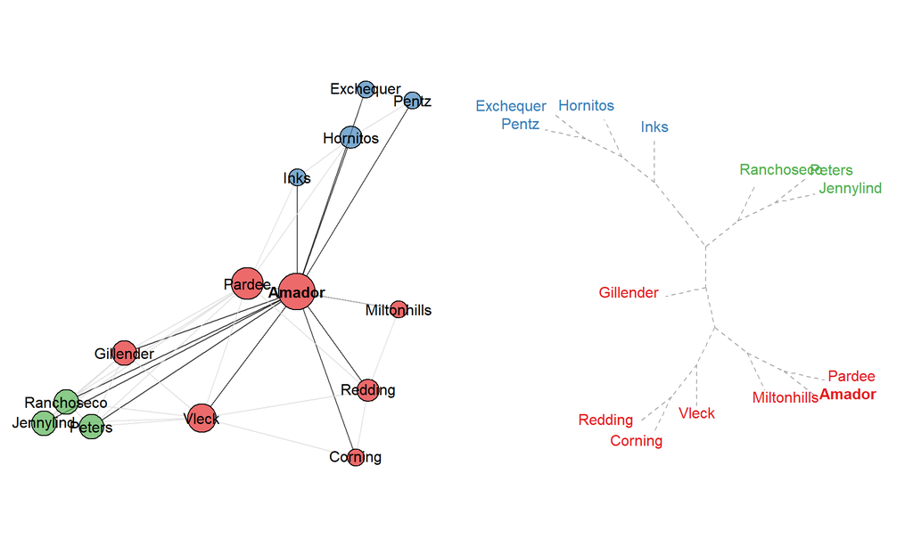

```r
# subset to components that are correlated to a soil series
idx <- which(s$sib.data$compkind == 'Series' & !is.na(s$sib.data$comppct_r))
s.sub <- s$sib.data[idx, ]

# convert into adjacency matrix
m <- component.adj.matrix(s.sub, mu = 'mukey', co = 'compname', wt = 'comppct_r')

# plot network diagram, with Amador soil highlighted
par(mar=c(0.5,0.5,0.5,0.5), mfcol=c(1,2))
plotSoilRelationGraph(m, s='Amador', vertex.scaling.factor=2, edge.transparency=0.75, edge.col=grey(0.85), edge.highlight.col='black', vertex.label.family='sans')
plotSoilRelationGraph(m, s='Amador', plot.style='dendrogram', type='unrooted', use.edge.length=FALSE)
```

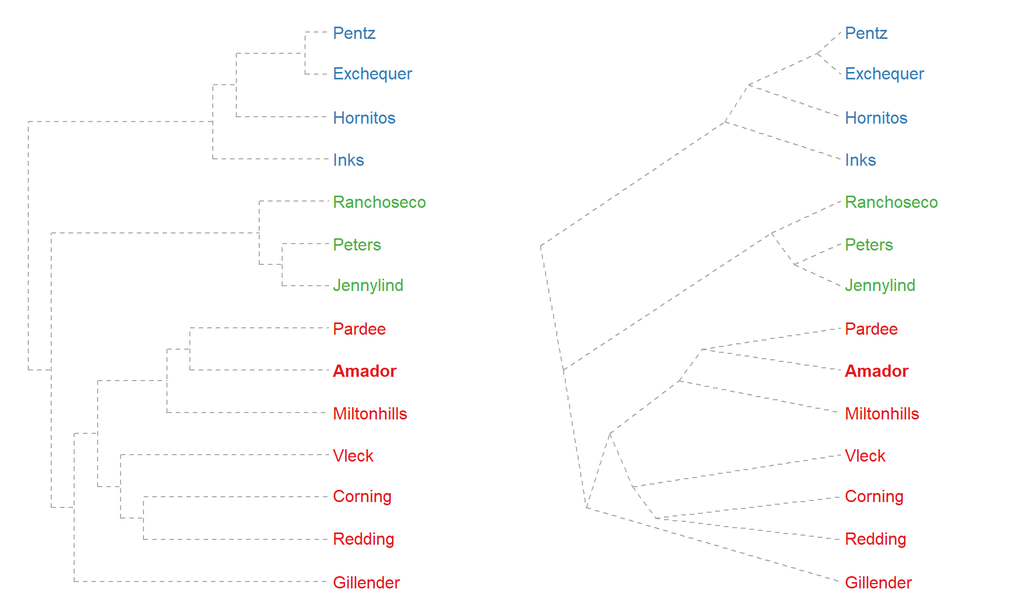

```r
par(mar=c(0.5,0.5,0.5,0.5), mfcol=c(1,2))
plotSoilRelationGraph(m, s='Amador', plot.style='dendrogram', type='phylogram')
plotSoilRelationGraph(m, s='Amador', plot.style='dendrogram', type='cladogram')
```

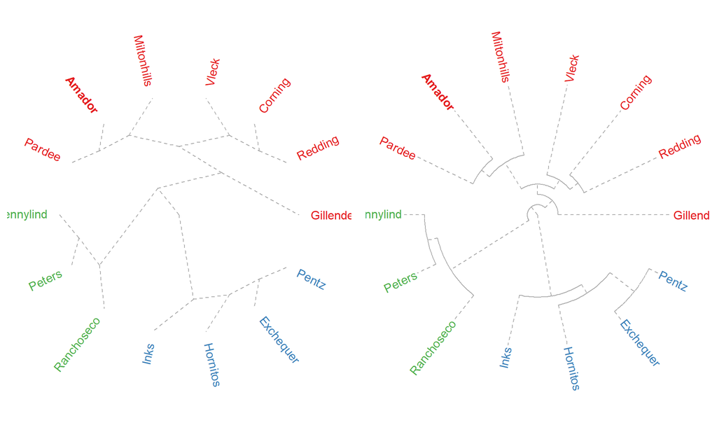

```r
par(mar=c(0.5,0.5,0.5,0.5), mfcol=c(1,2))
plotSoilRelationGraph(m, s='Amador', plot.style='dendrogram', type='radial')
plotSoilRelationGraph(m, s='Amador', plot.style='dendrogram', type='fan')
```

## 5.3 Cousins

*Finish this*

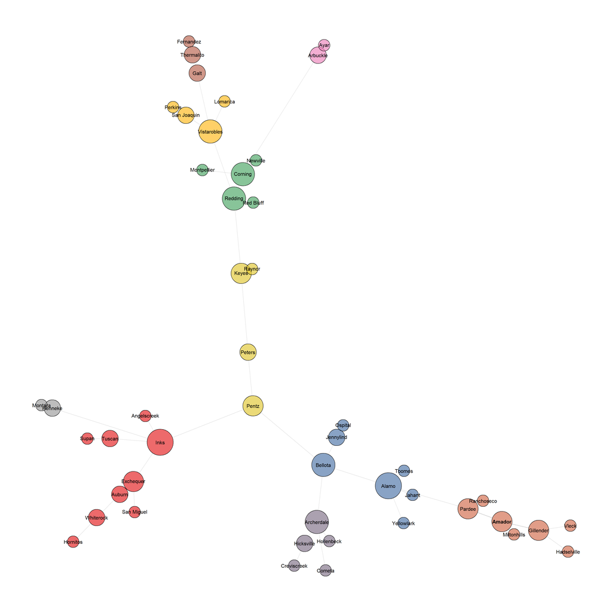

```r
# takes a while to run, there will be duplicates in cousins here
s <- siblings('amador', component.data = TRUE, cousins = TRUE)

# combine sibling + cousin data, remove duplicates
d <- unique(rbind(s$sib.data, s$cousin.data))

# subset to components that are correlated to a soil series
d <- d[which(d$compkind == 'Series'), ]

# convert into adjacency matrix
m <- component.adj.matrix(d, mu = 'mukey', co = 'compname', wt = 'comppct_r')

par(mar=c(1,1,1,1))
plotSoilRelationGraph(m, s='Amador', vertex.scaling.factor=1, edge.transparency=0.25, edge.col=grey(0.5), edge.highlight.col='black', vertex.label.family='sans', spanning.tree = 'max')
```

# 6 OSD Full Text Search

[OSD Full Text Search](http://soilmap2-1.lawr.ucdavis.edu/osd-search/)

```r
soils <- OSDquery(brief_narrative = 'andesite', mlra = '18')
kable_styling(kable(head(soils), format = 'html'), full_width = FALSE)
```

| score | series | family |
| --- | --- | --- |
| 0.0573088 | ARGONAUT | fine, mixed, superactive, thermic mollic haploxeralfs |
| 0.0573088 | BELLOTA | fine-loamy, mixed, superactive, thermic abruptic durixeralfs |
| 0.0573088 | EXCHEQUER | loamy, mixed, superactive, nonacid, thermic lithic xerorthents |
| 0.0573088 | HADSELVILLE | loamy, mixed, superactive, thermic, shallow entic ultic haploxerolls |
| 0.0573088 | IRON MOUNTAIN | loamy, mixed, superactive, mesic lithic ultic haploxerolls |
| 0.0573088 | KEYES | clayey, mixed, active, thermic, shallow abruptic durixeralfs |

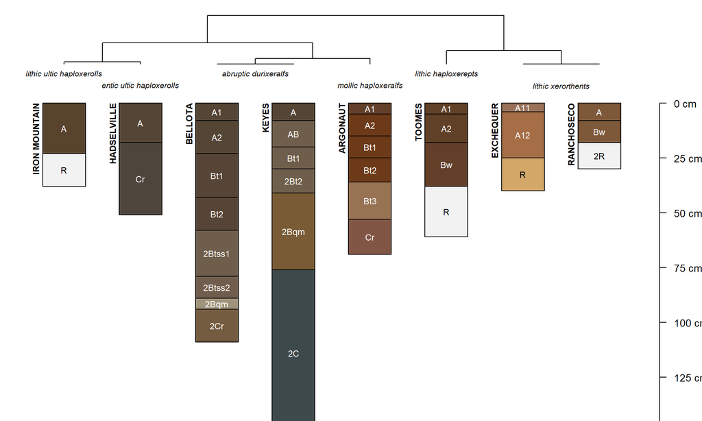

```r
s <- fetchOSD(soils$series)

par(mar = c(0, 0, 1, 1))
SoilTaxonomyDendrogram(s, y.offset = 0.4, scaling.factor = 0.0225, width = 0.28, name.style = 'center-center', depth.axis = list(line = -3))
```

```r
soils <- OSDquery(geog_location = 'strath & terrace', mlra='17,18')
str(soils)
```

```
## 'data.frame':    7 obs. of  3 variables:
##  $ score : num  0.1581 0.1436 0.1272 0.1272 0.0902 ...
##  $ series: chr  "HAMSLOUGH" "FALLAGER" "REDSWALE" "REDTOUGH" ...
##  $ family: chr  "clayey-skeletal, smectitic, thermic typic petraquepts" "clayey, mixed, superactive, thermic, shallow typic durixeralfs" "loamy-skeletal, mixed, superactive, thermic, shallow typic durixeralfs" "loamy, mixed, superactive, thermic, shallow typic durixeralfs" ...
```

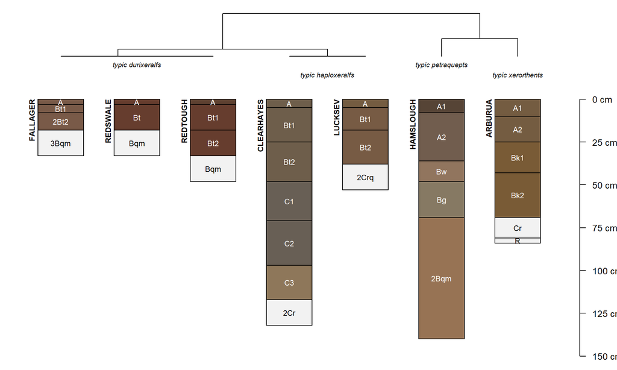

```r
s <- fetchOSD(soils$series)

par(mar = c(0,0,1,1))
SoilTaxonomyDendrogram(s, width=0.3, scaling.factor = 0.02, depth.axis = list(line = -3))
```

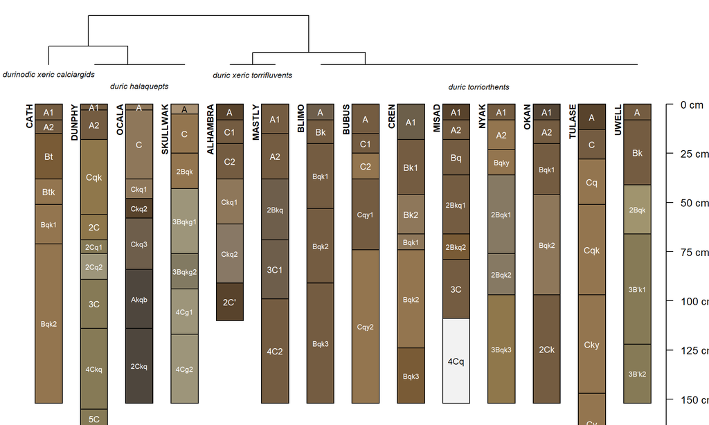

```r
soils <- OSDquery(taxonomic_class = 'duri:* & calc:*', mlra = '28B')

s <- fetchOSD(soils$series)

par(mar=c(0,0,1,1))
SoilTaxonomyDendrogram(s, y.offset = 0.4, width=0.3, scaling.factor = 0.02, shrink = TRUE, depth.axis = list(line = -3))
```

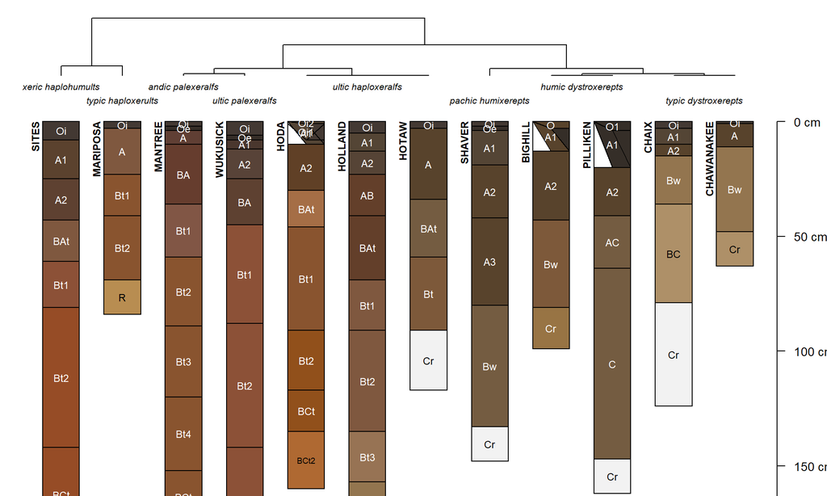

```r
soils <- OSDquery(geog_assoc_soils = 'musick')

s <- fetchOSD(soils$series, extended = TRUE)

par(mar=c(0,0,1,1))
SoilTaxonomyDendrogram(s$SPC, y.offset = 0.4, width=0.3, scaling.factor = 0.02, shrink = TRUE, depth.axis = list(line = -3))
```

```r
kable_styling(kable(s$mtnpos, digits = 2, format = 'html'), full_width = FALSE)
```

[output not shown]

```r
# kable(s$pmorigin)
```

# 7 A Classic Catena

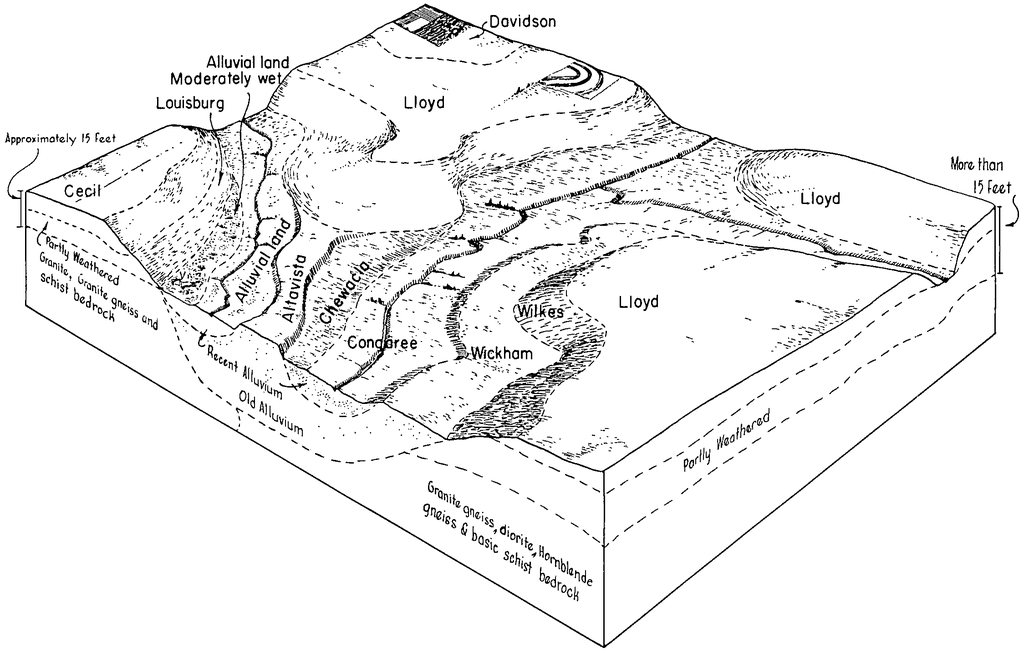

Diagram showing relationship of dominant soils in Lloyd-Davidson association (Soil Survey of Morgan County, Georgia; 1965).

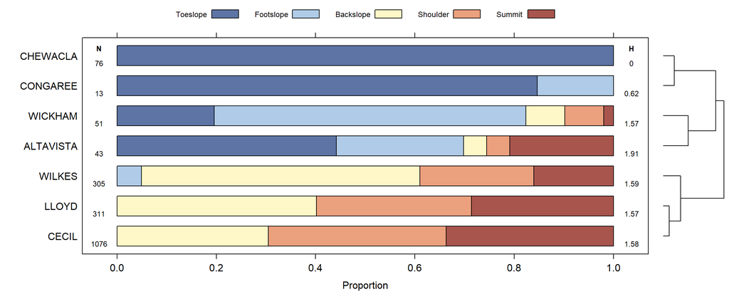

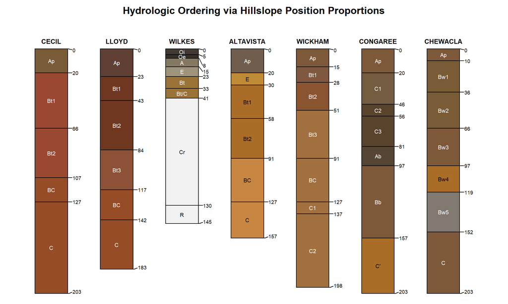

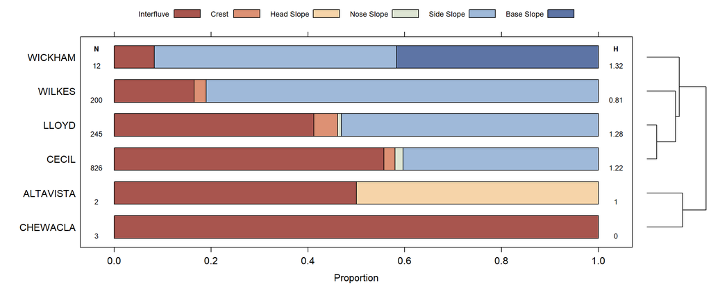

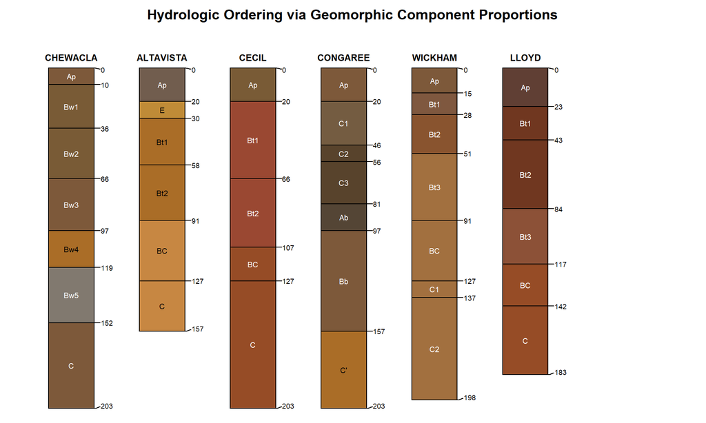

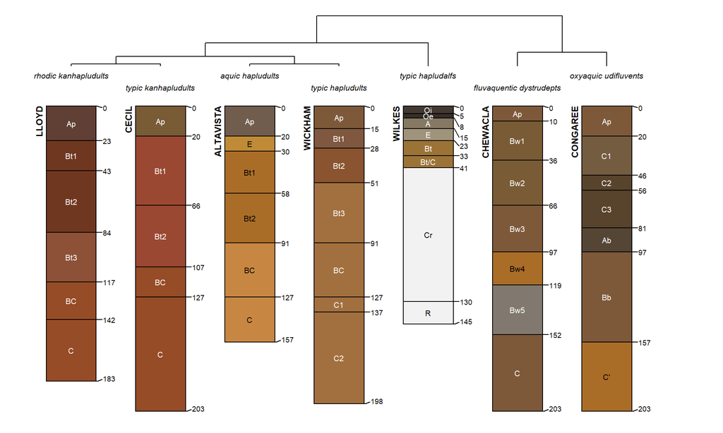

Code.

```r
soils <- c('cecil', 'altavista', 'lloyd', 'wickham', 'wilkes',  'chewacla', 'congaree')

# get morphology + extended summaries
s <- fetchOSD(soils, extended = TRUE)

res <- vizHillslopePosition(s$hillpos)
print(res$fig)

par(mar=c(0, 0, 2, 0))
plotSPC(s$SPC, plot.order = res$order, name.style = 'center-center', cex.names = 0.66, hz.depths = TRUE, hz.depths.offset = 0.05, fixLabelCollisions = TRUE, depth.axis = FALSE)
title('Hydrologic Ordering via Hillslope Position Proportions')

res <- vizGeomorphicComponent(s$geomcomp)
print(res$fig)

par(mar=c(0, 0, 2, 0))
plot(s$SPC, plot.order = res$order, name.style = 'center-center', cex.names = 0.66, hz.depths = TRUE, hz.depths.offset = 0.05, fixLabelCollisions = TRUE, depth.axis = FALSE)
title('Hydrologic Ordering via Geomorphic Component Proportions')

par(mar=c(0,0,1,1))
SoilTaxonomyDendrogram(s$SPC, y.offset = 0.4, scaling.factor = 0.015, name.style = 'center-center', cex.names = 0.66, hz.depths = TRUE, hz.depths.offset = 0.05, fixLabelCollisions = TRUE, depth.axis = FALSE, width = 0.28)
```

This document is based on `aqp` version 2.3.1, `soilDB` version 2.9.0, and `sharpshootR` version 2.4.1.